# Python Statistical Analysis in Practice — 02: Descriptive Statistics & EDA

*Author: Jason JJ Li · Peking University Institute of Population Research*

Before fitting any model, you must **look at your data**. This lecture builds a systematic toolkit for Exploratory Data Analysis (EDA) — the process of summarising, visualising, and understanding a dataset before any formal inference.

**What you will learn today:**

1. Central tendency: mean, median, mode — and when they disagree
2. Spread: variance, standard deviation, IQR, coefficient of variation
3. Distribution shape: skewness and kurtosis
4. The EDA visualisation toolkit: histogram, KDE, boxplot, violin, Q-Q plot
5. Outlier detection: z-score and IQR methods
6. Why you must always plot — Anscombe's Quartet
7. Bivariate EDA: scatter plots and correlation (Pearson vs Spearman)
8. Multivariate overview: pair plots and heatmaps
9. The full EDA pipeline — applied to a planted dataset

**The simulation bridge:** we generate every dataset with known parameters, run EDA, and confirm that what we find matches what we planted.

## Part 1: Setup

```python
import pandas as pd
import numpy as np
from scipy import stats
import matplotlib.pyplot as plt
import matplotlib.gridspec as gridspec
import seaborn as sns
import warnings

warnings.filterwarnings('ignore')
plt.style.use('seaborn-v0_8-whitegrid')
pd.set_option('display.precision', 3)
pd.set_option('display.float_format', '{:.3f}'.format)

COLORS = {
    'primary':   '#2E86AB',
    'secondary': '#A23B72',
    'accent':    '#F18F01',
    'success':   '#27AE60',
    'danger':    '#E74C3C',
    'neutral':   '#95A5A6',
}
RNG = np.random.default_rng(42)

import scipy
print('Libraries loaded.')
print(f'NumPy {np.__version__}  |  Pandas {pd.__version__}  |  Scipy {scipy.__version__}')
```

```
Libraries loaded.
NumPy 2.4.2  |  Pandas 2.3.3  |  Scipy 1.16.2
```

## Part 2: Central Tendency — Mean, Median, and Mode

The three measures of central tendency each answer a slightly different question:

| Measure | What it measures | Best used when |
| --- | --- | --- |
| **Mean** | Arithmetic average — sum / n | Data is roughly symmetric, no extreme values |
| **Median** | Middle value (50th percentile) | Data is skewed, or outliers are present |
| **Mode** | Most frequent value | Categorical data, or multimodal distributions |

### 2.1 When Mean ≈ Median: Symmetric Data

For a symmetric distribution, all three measures cluster together.

```
=== Symmetric distribution (Normal, μ=100, σ=15) ===
  Mean   : 99.173
  Median : 99.663
  Mode   : 105.0  (rounded to integers)
  Mean - Median = -0.490  ← close to 0 for symmetric data
```

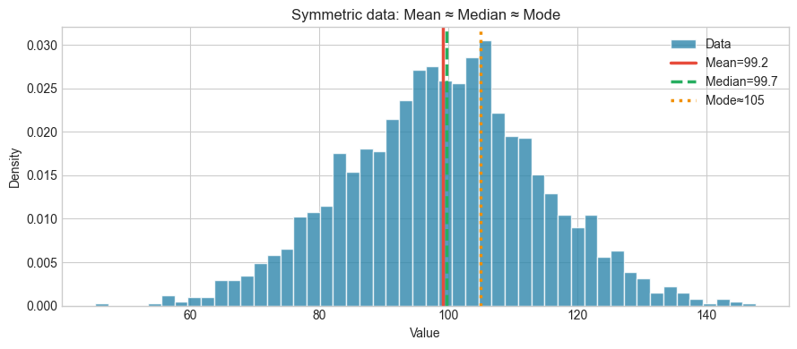

```python
# Symmetric normal distribution
sym_data = RNG.normal(loc=100, scale=15, size=2000)

mean_val   = sym_data.mean()
median_val = np.median(sym_data)
mode_val   = stats.mode(sym_data.round(0), keepdims=True).mode[0]

print('=== Symmetric distribution (Normal, μ=100, σ=15) ===')
print(f'  Mean   : {mean_val:.3f}')
print(f'  Median : {median_val:.3f}')
print(f'  Mode   : {mode_val:.1f}  (rounded to integers)')
print(f'  Mean - Median = {mean_val - median_val:.3f}  ← close to 0 for symmetric data')

fig, ax = plt.subplots(figsize=(9, 4))
ax.hist(sym_data, bins=50, density=True, color=COLORS['primary'],
        edgecolor='white', alpha=0.8, label='Data')
ax.axvline(mean_val,   color=COLORS['danger'],  linestyle='-',  lw=2.5, label=f'Mean={mean_val:.1f}')
ax.axvline(median_val, color=COLORS['success'], linestyle='--', lw=2.5, label=f'Median={median_val:.1f}')
ax.axvline(mode_val,   color=COLORS['accent'],  linestyle=':',  lw=2.5, label=f'Mode≈{mode_val:.0f}')
ax.set_xlabel('Value'); ax.set_ylabel('Density')
ax.set_title('Symmetric data: Mean ≈ Median ≈ Mode')
ax.legend()
plt.tight_layout()
plt.show()
```

### 2.2 When Mean ≠ Median: Right-Skewed Data

Right-skewed distributions — income, house prices, hospital stay durations — have a long right tail that **pulls the mean upward** but leaves the median unaffected.

> **Rule of thumb:** if Mean > Median, the distribution is right-skewed. Report the **median** (and IQR) as the primary summary, not the mean.

```
=== Right-skewed distribution (simulated income) ===
  Mean   : ¥50,744   ← pulled up by high earners
  Median : ¥36,714   ← a more typical value
  Mode   : ¥19,000   (rounded to nearest 1000)
  Mean / Median = 1.38x  ← mean is 38% above median

  → For income data, official statistics use MEDIAN income.
    A small number of very high earners inflates the mean.
```

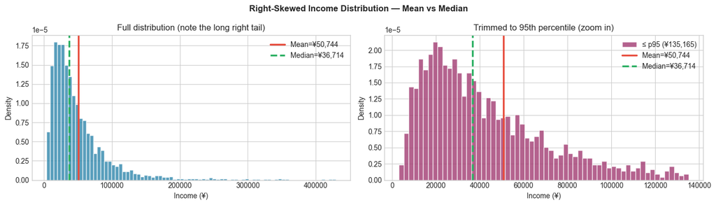

```python
# Simulate a right-skewed income-like distribution
# Log-normal: log(X) ~ Normal so X itself is right-skewed
income_data = RNG.lognormal(mean=10.5, sigma=0.8, size=2000)  # income in yuan

mean_inc   = income_data.mean()
median_inc = np.median(income_data)
mode_inc   = stats.mode(income_data.round(-3), keepdims=True).mode[0]

print('=== Right-skewed distribution (simulated income) ===')
print(f'  Mean   : ¥{mean_inc:,.0f}   ← pulled up by high earners')
print(f'  Median : ¥{median_inc:,.0f}   ← a more typical value')
print(f'  Mode   : ¥{mode_inc:,.0f}   (rounded to nearest 1000)')
print(f'  Mean / Median = {mean_inc/median_inc:.2f}x  ← mean is {(mean_inc/median_inc-1)*100:.0f}% above median')
print()
print('  → For income data, official statistics use MEDIAN income.')
print('    A small number of very high earners inflates the mean.')

fig, (ax1, ax2) = plt.subplots(1, 2, figsize=(14, 4))
fig.suptitle('Right-Skewed Income Distribution — Mean vs Median', fontsize=12, fontweight='bold')

# Left: full range
ax1.hist(income_data, bins=80, density=True, color=COLORS['primary'],
         edgecolor='white', alpha=0.8)
ax1.axvline(mean_inc,   color=COLORS['danger'],  lw=2.5, linestyle='-',  label=f'Mean=¥{mean_inc:,.0f}')
ax1.axvline(median_inc, color=COLORS['success'], lw=2.5, linestyle='--', label=f'Median=¥{median_inc:,.0f}')
ax1.set_xlabel('Income (¥)'); ax1.set_ylabel('Density')
ax1.set_title('Full distribution (note the long right tail)')
ax1.legend()

# Right: trimmed to p95 for better view
p95 = np.percentile(income_data, 95)
trimmed = income_data[income_data <= p95]
ax2.hist(trimmed, bins=60, density=True, color=COLORS['secondary'],
         edgecolor='white', alpha=0.8, label=f'≤ p95 (¥{p95:,.0f})')
ax2.axvline(mean_inc,   color=COLORS['danger'],  lw=2.5, linestyle='-',  label=f'Mean=¥{mean_inc:,.0f}')
ax2.axvline(median_inc, color=COLORS['success'], lw=2.5, linestyle='--', label=f'Median=¥{median_inc:,.0f}')
ax2.set_xlabel('Income (¥)'); ax2.set_ylabel('Density')
ax2.set_title('Trimmed to 95th percentile (zoom in)')
ax2.legend()
plt.tight_layout()
plt.show()
```

### 2.3 Bimodal Distributions: Mode Reveals What Mean and Median Hide

If a dataset has two peaks (bimodal), the mean and median both land *between* the peaks — a value that no one actually has. The mode is the only measure that captures multi-peakedness.

```
=== Bimodal distribution (mixed heights) ===
  Mean   : 167.0 cm  ← between both groups
  Median : 166.5 cm  ← between both groups

  → Neither mean nor median tells you there are TWO sub-populations.
    Always visualise!
```

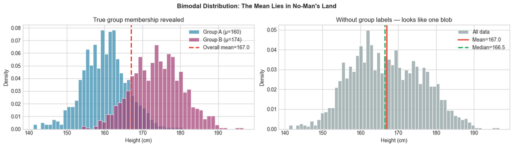

```python
# Simulate a bimodal distribution: two groups mixed together
group_A = RNG.normal(loc=160, scale=6, size=800)   # e.g. female heights
group_B = RNG.normal(loc=174, scale=7, size=800)   # e.g. male heights
mixed   = np.concatenate([group_A, group_B])

print('=== Bimodal distribution (mixed heights) ===')
print(f'  Mean   : {mixed.mean():.1f} cm  ← between both groups')
print(f'  Median : {np.median(mixed):.1f} cm  ← between both groups')
print()
print('  → Neither mean nor median tells you there are TWO sub-populations.')
print('    Always visualise!')

fig, axes = plt.subplots(1, 2, figsize=(14, 4))
fig.suptitle("Bimodal Distribution: The Mean Lies in No-Man's Land", fontsize=12, fontweight='bold')

# Left: mixed, coloured by true group
axes[0].hist(group_A, bins=40, density=True, color=COLORS['primary'],   alpha=0.7, edgecolor='white', label='Group A (μ=160)')
axes[0].hist(group_B, bins=40, density=True, color=COLORS['secondary'], alpha=0.7, edgecolor='white', label='Group B (μ=174)')
axes[0].axvline(mixed.mean(), color=COLORS['danger'], lw=2.5, linestyle='--', label=f'Overall mean={mixed.mean():.1f}')
axes[0].set_xlabel('Height (cm)'); axes[0].set_ylabel('Density')
axes[0].set_title('True group membership revealed')
axes[0].legend()

# Right: same data, group unknown
axes[1].hist(mixed, bins=60, density=True, color=COLORS['neutral'], alpha=0.8, edgecolor='white', label='All data')
axes[1].axvline(mixed.mean(),       color=COLORS['danger'],  lw=2.5, linestyle='-',  label=f'Mean={mixed.mean():.1f}')
axes[1].axvline(np.median(mixed),   color=COLORS['success'], lw=2.5, linestyle='--', label=f'Median={np.median(mixed):.1f}')
axes[1].set_xlabel('Height (cm)'); axes[1].set_ylabel('Density')
axes[1].set_title('Without group labels — looks like one blob')
axes[1].legend()
plt.tight_layout()
plt.show()
```